# HW2

Marco Tinga

01/05/2020

## R Markdown

```r
Corona=read.csv('https://raw.githubusercontent.com/MarcoTinga/LU_QA_2020/master/Datasets/Corona_mergedV-Dem.csv')

names(Corona)
```

```
##  [1] "country"         "ISOcode"         "cases"           "deaths"
##  [5] "popdata2018"     "popdata2018_log" "cases_log"       "deaths_log"
##  [9] "ccode"           "X_merge"         "country_name"    "country_id"
## [13] "v2x_polyarchy"   "v2x_libdem"      "v2x_partipdem"
```

```r
head(Corona)
```

```
##                    country ISOcode  cases deaths popdata2018 popdata2018_log
## 1 United_States_of_America     USA 609516  26057   327167434        8.514770
## 2                   Canada     CAN  27046    903    37058856        7.568892
## 3                     Cuba     CUB    766     21    11338138        7.054542
## 4                    Haiti     HTI     40      3    11123176        7.046229
## 5       Dominican_Republic     DOM   3286    183    10627165        7.026417
## 6                  Jamaica     JAM    105      5     2934855        6.467587
##   cases_log deaths_log ccode                       X_merge
## 1  5.784986  4.4159412     2 both in master and using data
## 2  4.432119  2.9561684    20 both in master and using data
## 3  2.884795  1.3424227    40 both in master and using data
## 4  1.612784  0.6020600    41 both in master and using data
## 5  3.516800  2.2648177    42 both in master and using data
## 6  2.025306  0.7781513    51 both in master and using data
##               country_name country_id v2x_polyarchy v2x_libdem v2x_partipdem
## 1 United States of America         20         0.798      0.700         0.566
## 2                   Canada         66         0.866      0.776         0.619
## 3                     Cuba        155         0.203      0.090         0.133
## 4                    Haiti         26         0.449      0.239         0.254
## 5       Dominican Republic        114         0.598      0.322         0.383
## 6                  Jamaica        120         0.810      0.690         0.559
```

```r
summary(Corona$cases_log)
```

```
##    Min. 1st Qu.  Median    Mean 3rd Qu.    Max.
##   0.301   1.827   2.818   2.761   3.532   5.785
```

```r
summary(Corona$v2x_polyarchy)
```

```
##    Min. 1st Qu.  Median    Mean 3rd Qu.    Max.
##  0.0230  0.3115  0.5580  0.5350  0.7835  0.9000
```

```r
summary(Corona$v2x_libdem)
```

```
##    Min. 1st Qu.  Median    Mean 3rd Qu.    Max.
##  0.0120  0.1755  0.3960  0.4148  0.6480  0.8580
```

```r
summary(Corona$v2x_partipdem)
```

```
##    Min. 1st Qu.  Median    Mean 3rd Qu.    Max.
##  0.0160  0.1735  0.3300  0.3437  0.5025  0.7760
```

```r
library(ggplot2)

library(GGally)

options(scipen=999)
```

## Question a) Visualizing the distribution of the following variables: cases_log, v2x_polyarchy, v2x_libdem, v2x_partipdem.

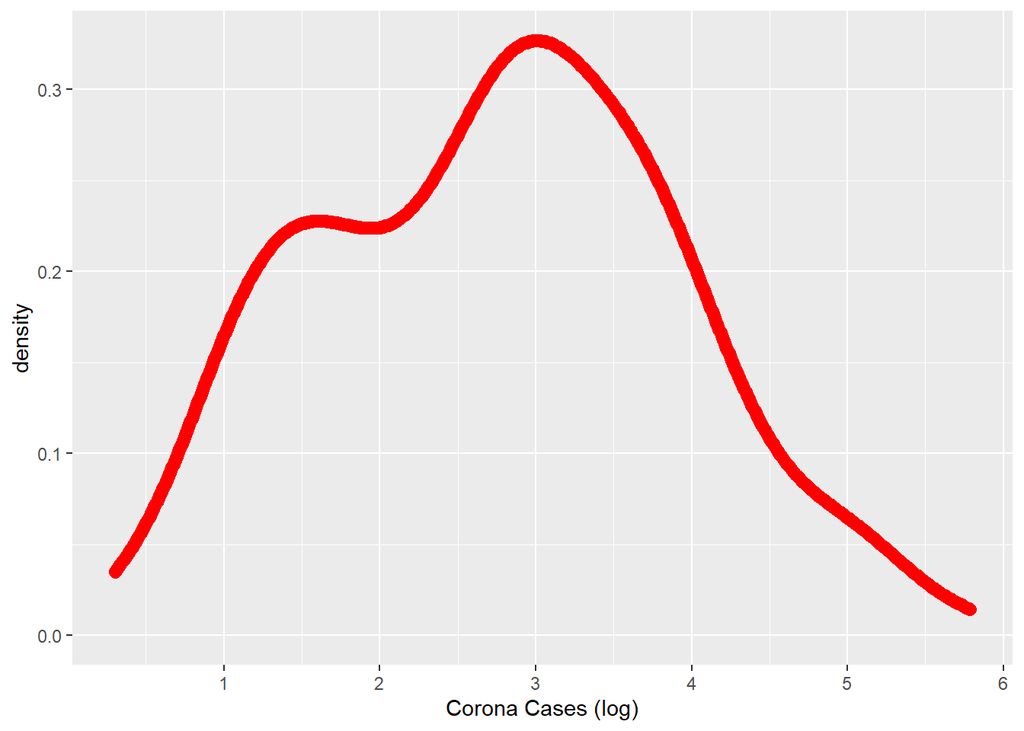

```r
ggplot(Corona,
       aes(x = cases_log)) +
  geom_density(col='red', lwd=3)+labs(x="Corona Cases (log)")
```

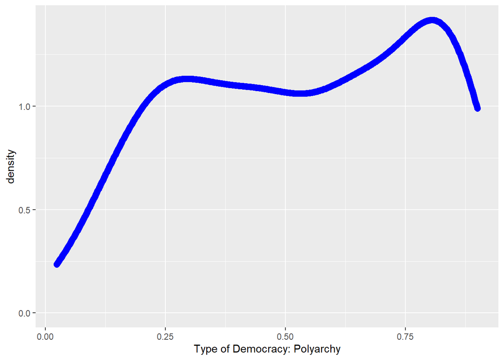

```r
ggplot(Corona,
       aes(x = v2x_polyarchy)) +
  geom_density(col='blue', lwd=3)+labs(x='Type of Democracy: Polyarchy')
```

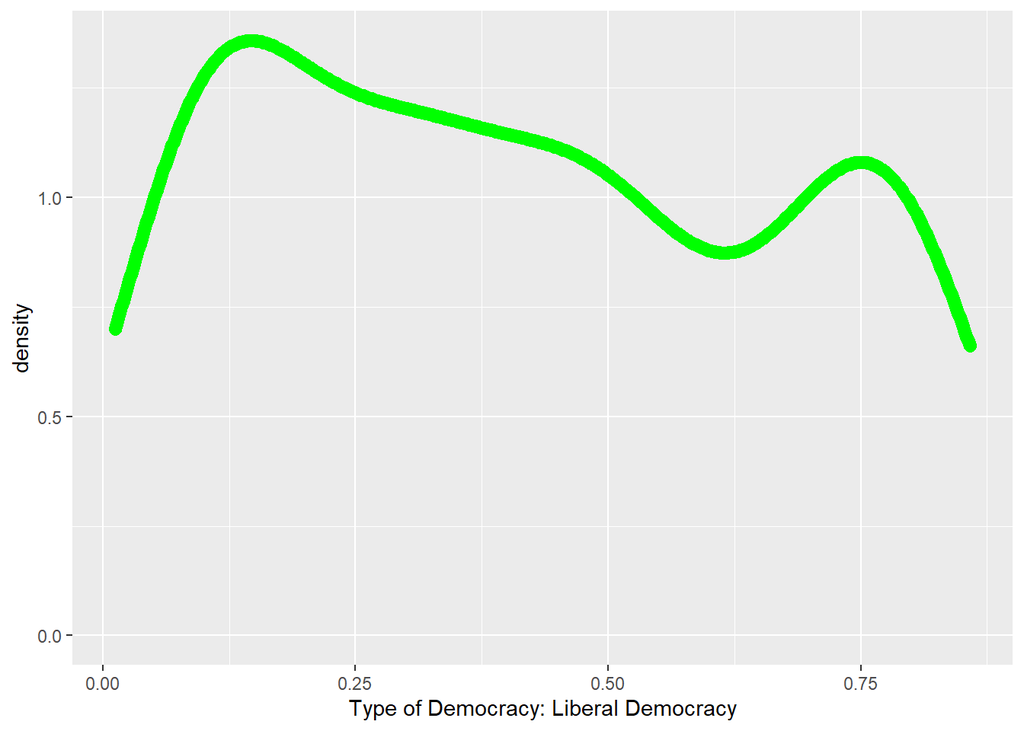

```r
ggplot(Corona,
       aes(x = v2x_libdem)) +
  geom_density(col='green', lwd=3)+labs(x="Type of Democracy: Liberal Democracy")
```

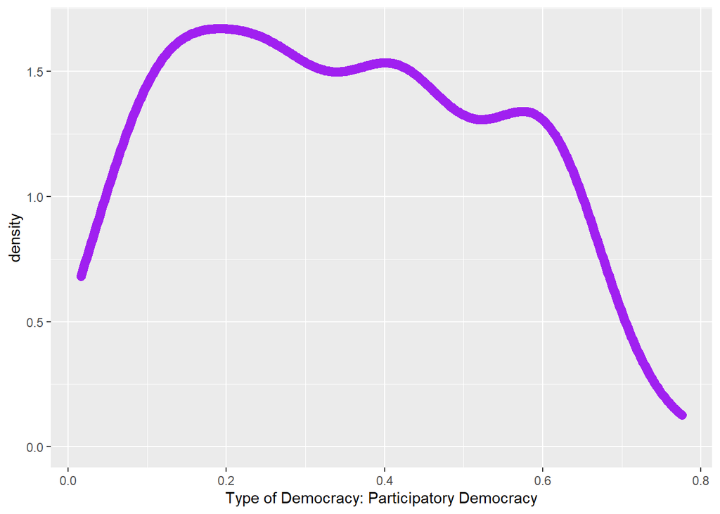

```r
ggplot(Corona,
       aes(x = v2x_partipdem)) +
  geom_density(col='purple', lwd=3)+labs(x="Type of Democracy: Participatory Democracy")
```

## Question b)Reproducing the matrix plot at page 6 of the HW.

First possible method.

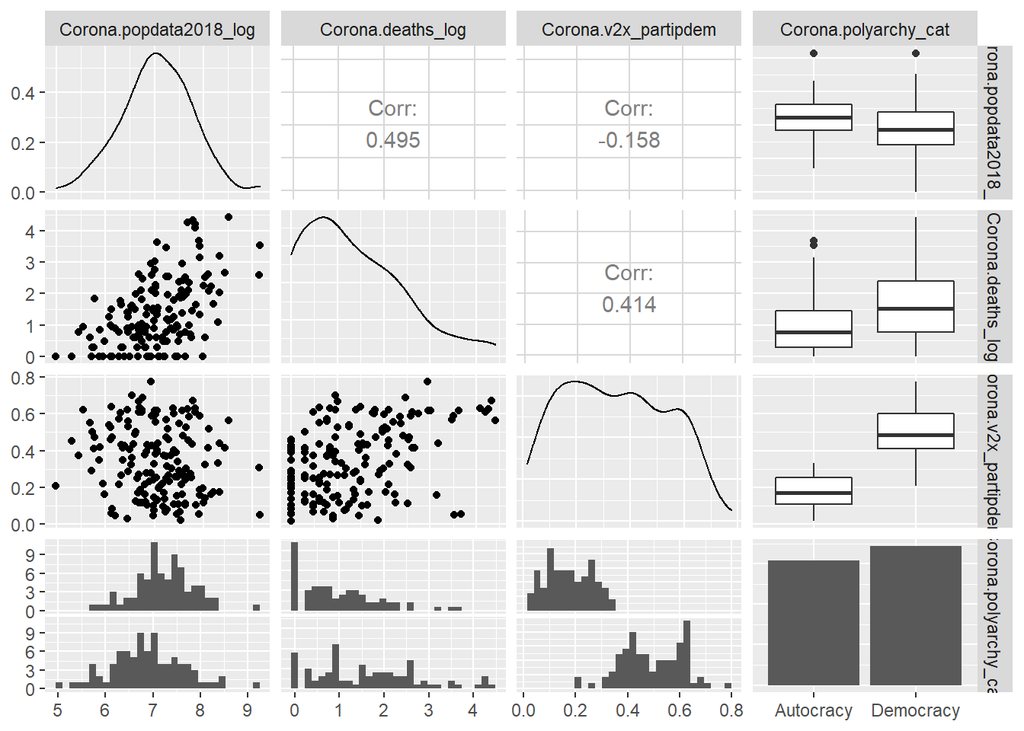

```r
Corona$polyarchy_cat=ifelse(Corona$v2x_polyarchy> .5, "Democracy", "Autocracy")

Corona$polyarchy_cat=factor(Corona$polyarchy_cat)

Plot1=data.frame(Corona$popdata2018_log,Corona$deaths_log,Corona$v2x_partipdem,Corona$polyarchy_cat)

ggpairs(Plot1)
```

## Question b)

Alternative method.

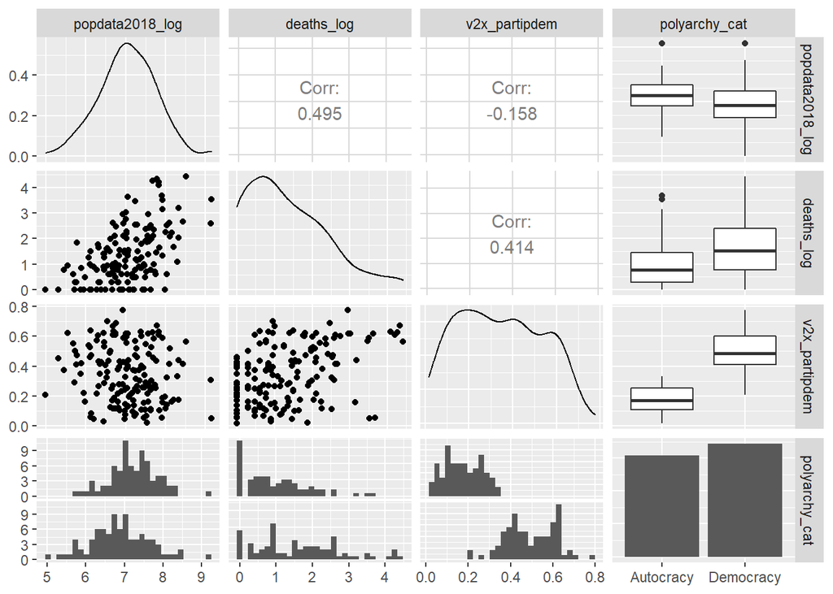

```r
ggpairs(Corona, columns = c("popdata2018_log", "deaths_log", "v2x_partipdem", "polyarchy_cat"))
```

## Question c) Defining the categorical variables of democracy indices and plotting the association of these variables with cases_log.

First possible method, using a matrix plot as in question b).

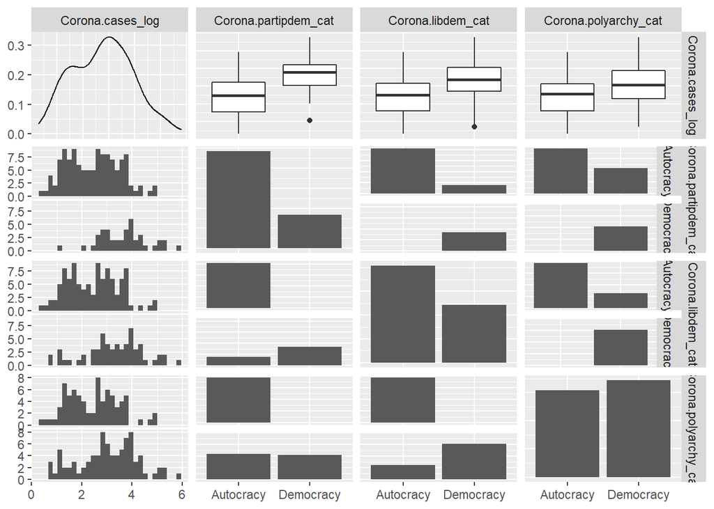

```r
Corona$libdem_cat=ifelse(Corona$v2x_libdem> .5, "Democracy", "Autocracy")

Corona$libdem_cat=factor(Corona$libdem_cat)

Corona$partipdem_cat=ifelse(Corona$v2x_partipdem> .5, "Democracy", "Autocracy")

Corona$partipdem_cat=factor(Corona$partipdem_cat)

Plot2=data.frame(Corona$cases_log,Corona$partipdem_cat,Corona$libdem_cat,Corona$polyarchy_cat)

ggpairs(Plot2)
```

## Question c)

Alternative method, using individual boxplots for each Type of democracy.

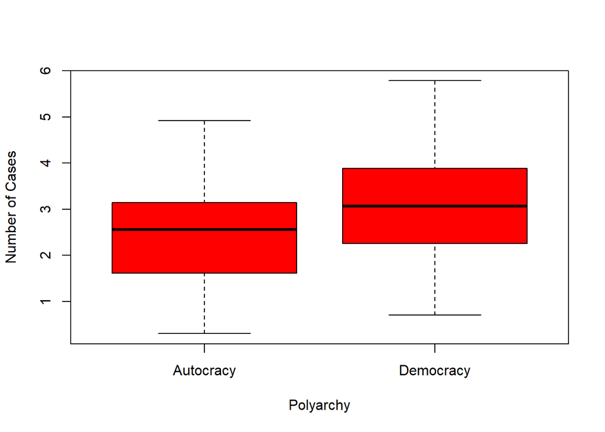

```r
Corona$polyarchy_cat=ifelse(Corona$v2x_polyarchy> .5, "Democracy", "Autocracy")

Corona$polyarchy_cat<-factor(Corona$polyarchy_cat)

boxplot(Corona$cases_log~Corona$polyarchy_cat,
        col='red',
        xlab='Polyarchy', ylab='Number of Cases')
```

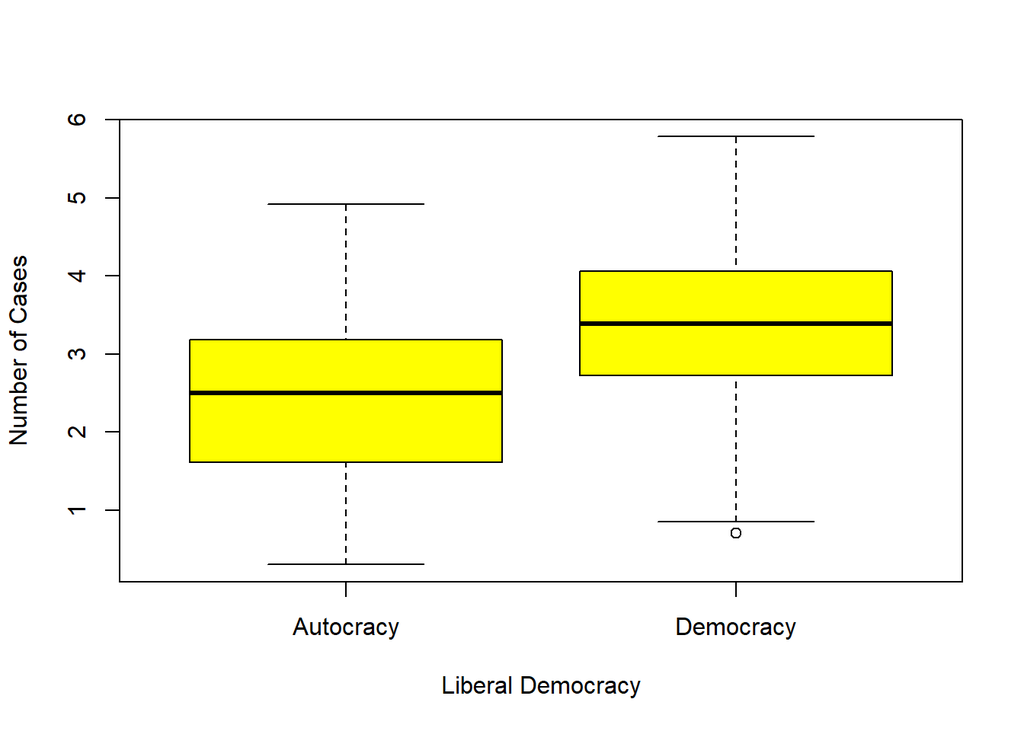

```r
boxplot(Corona$cases_log~Corona$libdem_cat,
        col='yellow',
        xlab='Liberal Democracy', ylab='Number of Cases')
```

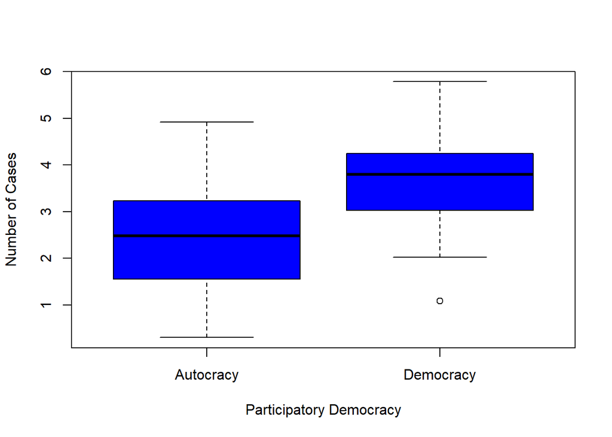

```r
boxplot(Corona$cases_log~Corona$partipdem_cat,
        col='blue',
        xlab='Participatory Democracy', ylab='Number of Cases')
```

## Question d) Estimating the five functions as shown in the HW and discussing their results.

## (1) cases_log=β0+β1v2x_polyarchy+ϵ

Number of corona cases (log) in function of type of democracy: Polyarchy.

```r
OLS_m1=lm(cases_log~v2x_polyarchy, data=Corona)

summary(OLS_m1)
```

```
##
## Call:
## lm(formula = cases_log ~ v2x_polyarchy, data = Corona)
##
## Residuals:
##      Min       1Q   Median       3Q      Max
## -2.31471 -0.69695 -0.00291  0.79433  2.83502
##
## Coefficients:
##               Estimate Std. Error t value             Pr(>|t|)
## (Intercept)     1.9619     0.2034   9.646 < 0.0000000000000002 ***
## v2x_polyarchy   1.4940     0.3450   4.330            0.0000261 ***
## ---
## Signif. codes:  0 '***' 0.001 '**' 0.01 '*' 0.05 '.' 0.1 ' ' 1
##
## Residual standard error: 1.091 on 161 degrees of freedom
## Multiple R-squared:  0.1043, Adjusted R-squared:  0.09876
## F-statistic: 18.75 on 1 and 161 DF,  p-value: 0.00002608
```

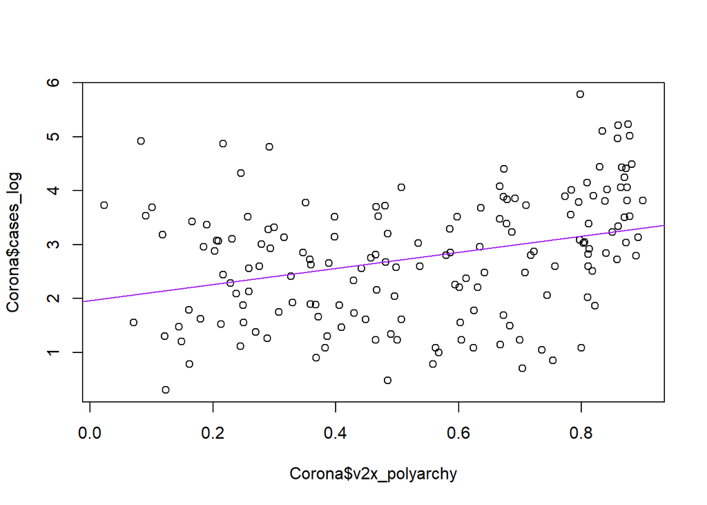

```r
plot(Corona$v2x_polyarchy,Corona$cases_log)

abline(lm(Corona$cases_log ~ Corona$v2x_polyarchy), col = "purple")
```

## (2)cases_log=β0+β1v2x_libdem+ϵ

Number of corona cases (log) in function of type of democracy: Liberal Democracy.

```r
OLS_m2=lm(cases_log~v2x_libdem, data=Corona)

summary(OLS_m2)
```

```
##
## Call:
## lm(formula = cases_log ~ v2x_libdem, data = Corona)
##
## Residuals:
##      Min       1Q   Median       3Q      Max
## -2.32986 -0.67076  0.06097  0.79488  2.77711
##
## Coefficients:
##             Estimate Std. Error t value             Pr(>|t|)
## (Intercept)   2.0592     0.1605  12.828 < 0.0000000000000002 ***
## v2x_libdem    1.6922     0.3302   5.125          0.000000844 ***
## ---
## Signif. codes:  0 '***' 0.001 '**' 0.01 '*' 0.05 '.' 0.1 ' ' 1
##
## Residual standard error: 1.069 on 161 degrees of freedom
## Multiple R-squared:  0.1402, Adjusted R-squared:  0.1349
## F-statistic: 26.26 on 1 and 161 DF,  p-value: 0.0000008441
```

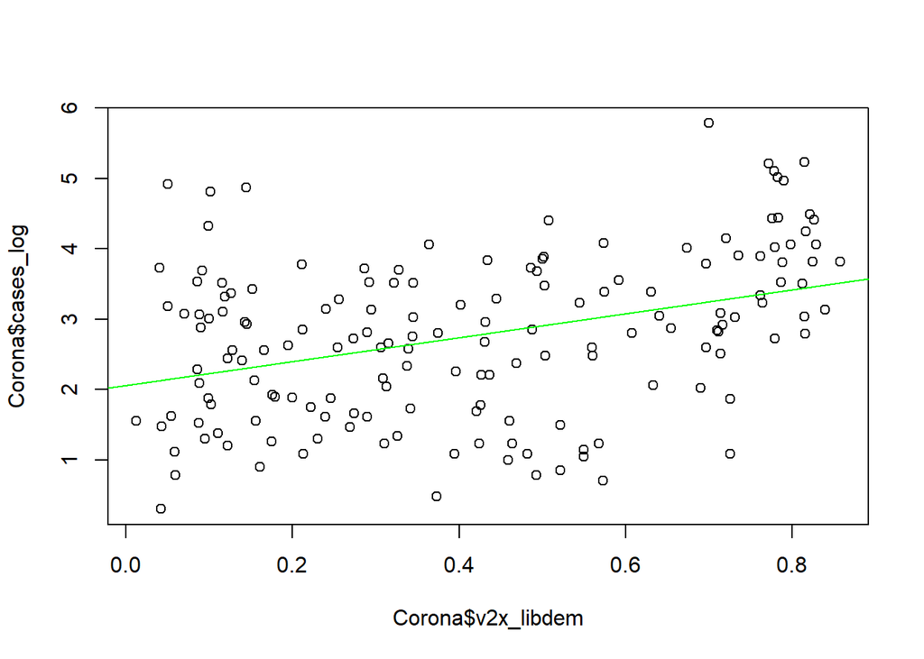

```r
plot(Corona$v2x_libdem,Corona$cases_log)

abline(lm(Corona$cases_log ~ Corona$v2x_libdem), col = "green")
```

## (3)cases_log=β0+β1v2x_partipdem+ϵ

Number of corona cases (log) in function of type of democracy: Participatory Democracy.

```r
OLS_m3=lm(cases_log~v2x_partipdem,data=Corona)

summary(OLS_m3)
```

```
##
## Call:
## lm(formula = cases_log ~ v2x_partipdem, data = Corona)
##
## Residuals:
##      Min       1Q   Median       3Q      Max
## -2.30577 -0.71433  0.00464  0.77544  2.82720
##
## Coefficients:
##               Estimate Std. Error t value             Pr(>|t|)
## (Intercept)     1.9880     0.1725  11.523 < 0.0000000000000002 ***
## v2x_partipdem   2.2494     0.4389   5.125          0.000000843 ***
## ---
## Signif. codes:  0 '***' 0.001 '**' 0.01 '*' 0.05 '.' 0.1 ' ' 1
##
## Residual standard error: 1.069 on 161 degrees of freedom
## Multiple R-squared:  0.1403, Adjusted R-squared:  0.1349
## F-statistic: 26.27 on 1 and 161 DF,  p-value: 0.0000008434
```

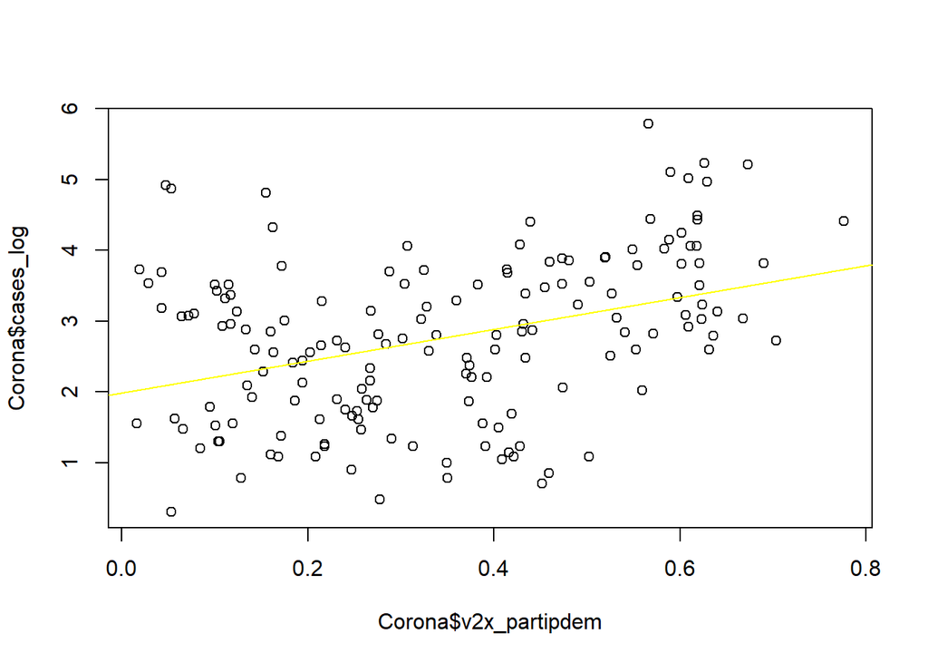

```r
plot(Corona$v2x_partipdem,Corona$cases_log)

abline(lm(Corona$cases_log ~ Corona$v2x_partipdem), col = "yellow")
```

## (4)cases_log=β0+β1v2x_polyarchy+β2v2x_libdem+β3v2x_partipdem+ϵ

Number of corona cases (log) in function of each type of democracy as co-variables.

```r
OLS_m4=lm(cases_log~v2x_polyarchy+v2x_libdem+v2x_partipdem, data=Corona)

summary(OLS_m4)
```

```
##
## Call:
## lm(formula = cases_log ~ v2x_polyarchy + v2x_libdem + v2x_partipdem,
##     data = Corona)
##
## Residuals:
##      Min       1Q   Median       3Q      Max
## -2.20338 -0.69834 -0.02883  0.76655  2.74390
##
## Coefficients:
##               Estimate Std. Error t value             Pr(>|t|)
## (Intercept)     2.6622     0.2562  10.392 < 0.0000000000000002 ***
## v2x_polyarchy  -5.5996     1.6452  -3.404             0.000842 ***
## v2x_libdem      4.1004     1.4380   2.852             0.004928 **
## v2x_partipdem   4.0546     1.6687   2.430             0.016219 *
## ---
## Signif. codes:  0 '***' 0.001 '**' 0.01 '*' 0.05 '.' 0.1 ' ' 1
##
## Residual standard error: 1.036 on 159 degrees of freedom
## Multiple R-squared:  0.2016, Adjusted R-squared:  0.1866
## F-statistic: 13.39 on 3 and 159 DF,  p-value: 0.00000007792
```

## (5)

## First Solution, as suggested in the HW.

Addition of population (2018 data) as a control variable. cases_log=β0+β1v2x_polyarchy+β2popdata2018+ϵ

```r
OLS_m5=lm(cases_log~v2x_polyarchy+popdata2018, data=Corona)

summary(OLS_m5)
```

```
##
## Call:
## lm(formula = cases_log ~ v2x_polyarchy + popdata2018, data = Corona)
##
## Residuals:
##     Min      1Q  Median      3Q     Max
## -2.2351 -0.6518  0.0457  0.8279  2.5522
##
## Coefficients:
##                      Estimate      Std. Error t value           Pr(>|t|)
## (Intercept)   1.7693316171526 0.2005447881739   8.823 0.0000000000000019 ***
## v2x_polyarchy 1.6536749080592 0.3325721423892   4.972 0.0000016980710644 ***
## popdata2018   0.0000000023709 0.0000000005233   4.531 0.0000114847457852 ***
## ---
## Signif. codes:  0 '***' 0.001 '**' 0.01 '*' 0.05 '.' 0.1 ' ' 1
##
## Residual standard error: 1.032 on 159 degrees of freedom
##   (1 observation deleted due to missingness)
## Multiple R-squared:  0.2024, Adjusted R-squared:  0.1924
## F-statistic: 20.18 on 2 and 159 DF,  p-value: 0.00000001554
```

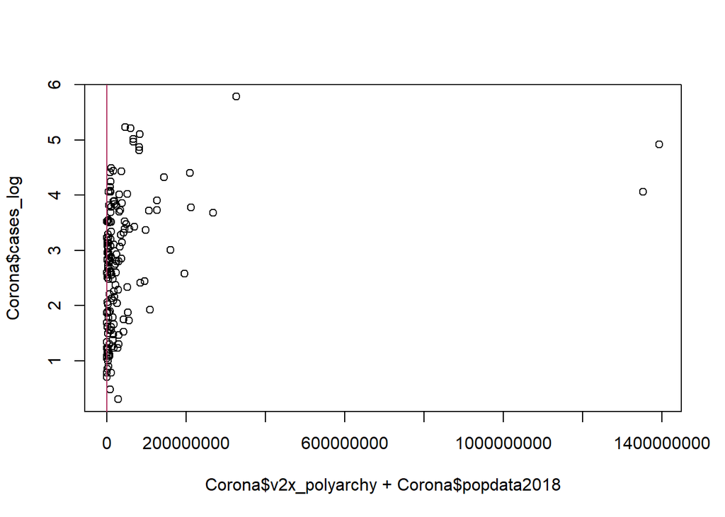

```r
plot(Corona$v2x_polyarchy+Corona$popdata2018,Corona$cases_log)

abline(lm(Corona$cases_log ~ Corona$v2x_polyarchy+Corona$popdata2018), col = "maroon")
```